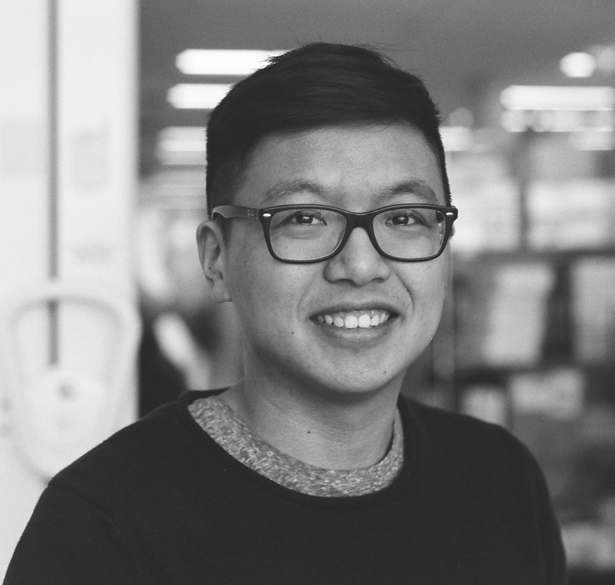

# Jeffrey J. Li

## About me

I’m a biologist with broad experiences from supporting drug discovery efforts using *in vitro* biochemistry to dissecting fundamental cellular mechanisms in tissue culture systems. I am currently a PhD student in the laboratory of Dr. Rachel Green at Johns Hopkins University. I’m broadly interested in how cells sense and respond to translational distress. Specifically, I’m interested in how this occurs at the level of the ribosome via two critical stress pathways, the ribotoxic stress response and the integrated stress response. Through this work, I have developed deep expertise in molecular biology and NGS/bioinformatics in mammalian cell culture settings.

Prior to starting my PhD, I worked as a protein biochemist at the Broad Institute’s Center for the Development of Therapeutics (CDoT). There I purified and characterized candidate proteins to support fragment-based screening and structural biology efforts as a part of multiple drug discovery campaigns. This experience further refined the skills I initially acquired during my Bachelor’s and Master’s theses at McGill University. At McGill, I was in Dr. Jason Young’s group, utilizing biochemical and biophysical techniques to characterize proteins involved in the heat shock response *in vitro*.

I am almost entirely self-taught in programming after learning about its utility during my last year of undergrad. I have significant experience in Python, R, and bash scripting, which has been incredibly helpful during my graduate work.

## Education

**Johns Hopkins University** | Baltimore, USA

Ph.D. | Biochemistry and Molecular Biology | August 2020 - Present (Expected May 2026)

**McGill University** | Montreal, Canada

M.Sc. | Biochemistry | May 2016 - February 2019

B.Sc. | Biochemistry | September 2013 - May 2016

## Experience

**Johns Hopkins University** | *Laboratory of Dr.Rachel Green* | PhD Candidate | April 2021 - Present

**Broad Institute of MIT and Harvard** | *Center for the Development of Therapeutics (CDoT)* | Research Associate II | December 2018 - December 2020

**McGill University** | *Laboratory of Dr. Jason C. Young* | BSc/MSc Candidate | May 2015 - August 2018

**Student Television at McGill (TVM)** | Technical Director | October 2015 - April 2017

## Publications

ORCID: 0009-0000-0871-2481

Kim KQ*, **Li JJ***, Nanjaraj Urs AN*, Pacheco ME, Lasehinde V, Denk T, Tesina P, Tomomatsu S, Matsuo Y, McDonald E, Beckmann R, Inada T, Green R, Zaher HS. (2024) *Mol Cell* | [**Multiprotein bridging factor 1 is required for robust activation of the integrated stress response on collided ribosomes.**](https://doi.org/10.1016/j.molcel.2024.10.029) *Equal contribution

Sinha NK, McKenney C, Yeow ZY*, **Li JJ***, Nam KH*, Yaron-Barir TM, Johnson JL, Huntsman EM, Cantley LC, Ordureau A, Regot S, Green R. (2024) *Cell* | [**The ribotoxic stress response drives UV-mediated cell death.**](https://doi.org/10.1016/j.cell.2024.05.018) *Equal contribution

Ranaghan MJ, **Li JJ**, Laprise DM, Garvie CW. (2021) *BMC Biology* | [**Assessing optimal: inequalities in codon optimization algorithms.**](https://doi.org/10.1186/s12915-021-00968-8)

*Last updated: Jan 7, 2026*